# The Philosophy Data Project

## - By Rishav Agarwal

[figure not shown]

# Introduction!

Based on a preliminary analysis of the dataset, this project hopes to answer the following questions:

1. The Text-Less years : What were the years were most of the school of thoughts and the authors within those schools did not product any relevant published texts?  
2. The Emotion-Sentiment of Philosophy : Can the texts written by authors and within the schools be classified into varying emotions or general sentiments? If yes, how would that look like?  
3. The Philosophy of Words : Can the basis of the author's philosophies be realized from their WordCloud representation?

# Let's talk about Data!

Before we dwell into analyzing what the data represents, we should first understand what the data looks like. The best way to gain insights from a given dataset is to break it down and understand the possible questions that can be answered by the given data. We will start with the displaying of the entire dataset, then slowly realizing the correlations between different schools of thoughts and different authors as given by the same.

**The History of Philosophy Dataset**

|  | title | author | school | sentence_spacy | sentence_str | original_publication_date | corpus_edition_date | sentence_length | sentence_lowered | tokenized_txt | lemmatized_str |
| --- | --- | --- | --- | --- | --- | --- | --- | --- | --- | --- | --- |
| 0 | Plato - Complete Works | Plato | plato | What's new, Socrates, to make you leave your ... | What's new, Socrates, to make you leave your ... | -350 | 1997 | 125 | what's new, socrates, to make you leave your ... | ['what', 'new', 'socrates', 'to', 'make', 'you... | what be new , Socrates , to make -PRON- lea... |
| 1 | Plato - Complete Works | Plato | plato | Surely you are not prosecuting anyone before t... | Surely you are not prosecuting anyone before t... | -350 | 1997 | 69 | surely you are not prosecuting anyone before t... | ['surely', 'you', 'are', 'not', 'prosecuting',... | surely -PRON- be not prosecute anyone before ... |
| 2 | Plato - Complete Works | Plato | plato | The Athenians do not call this a prosecution b... | The Athenians do not call this a prosecution b... | -350 | 1997 | 74 | the athenians do not call this a prosecution b... | ['the', 'athenians', 'do', 'not', 'call', 'thi... | the Athenians do not call this a prosecution ... |
| 3 | Plato - Complete Works | Plato | plato | What is this you say? | What is this you say? | -350 | 1997 | 21 | what is this you say? | ['what', 'is', 'this', 'you', 'say'] | what be this -PRON- say ? |
| 4 | Plato - Complete Works | Plato | plato | Someone must have indicted you, for you are no... | Someone must have indicted you, for you are no... | -350 | 1997 | 101 | someone must have indicted you, for you are no... | ['someone', 'must', 'have', 'indicted', 'you',... | someone must have indict -PRON- , for -PRON- ... |
| ... | ... | ... | ... | ... | ... | ... | ... | ... | ... | ... | ... |
| 360803 | Women, Race, And Class | Davis | feminism | But the socialization of housework including m... | But the socialization of housework including m... | 1981 | 1981 | 142 | but the socialization of housework including m... | ['but', 'the', 'socialization', 'of', 'housewo... | but the socialization of housework include me... |
| 360804 | Women, Race, And Class | Davis | feminism | The only significant steps toward endingdomest... | The only significant steps toward endingdomest... | 1981 | 1981 | 117 | the only significant steps toward endingdomest... | ['the', 'only', 'significant', 'steps', 'towar... | the only significant step toward endingdomest... |
| 360805 | Women, Race, And Class | Davis | feminism | Working women, therefore, have a special and v... | Working women, therefore, have a special and v... | 1981 | 1981 | 90 | working women, therefore, have a special and v... | ['working', 'women', 'therefore', 'have', 'spe... | working woman , therefore , have a special an... |
| 360806 | Women, Race, And Class | Davis | feminism | Moreover, under capitalism, campaigns for jobs... | Moreover, under capitalism, campaigns for jobs... | 1981 | 1981 | 199 | moreover, under capitalism, campaigns for jobs... | ['moreover', 'under', 'capitalism', 'campaigns... | moreover , under capitalism , campaign for jo... |
| 360807 | Women, Race, And Class | Davis | feminism | This strategy calls into question the validity... | This strategy calls into question the validity... | 1981 | 1981 | 126 | this strategy calls into question the validity... | ['this', 'strategy', 'calls', 'into', 'questio... | this strategy call into question the validity... |

360808 rows × 11 columns

Now let's drill down to see the number of distinct authors and school of thoughts presented by the dataset. This will help us determine the questions to be answered and make the reference point of analysis easier.

**Grouping the dataset by Authors**

| author | original_publication_date count | original_publication_date mean | original_publication_date std | original_publication_date min | original_publication_date 25% | original_publication_date 50% | original_publication_date 75% | original_publication_date max | corpus_edition_date count | corpus_edition_date mean | corpus_edition_date ... | corpus_edition_date 75% | corpus_edition_date max | sentence_length count | sentence_length mean | sentence_length std | sentence_length min | sentence_length 25% | sentence_length 50% | sentence_length 75% | sentence_length max |
| --- | --- | --- | --- | --- | --- | --- | --- | --- | --- | --- | --- | --- | --- | --- | --- | --- | --- | --- | --- | --- | --- |
| Aristotle | 48779.0 | -320.000000 | 0.000000 | -320.0 | -320.0 | -320.0 | -320.0 | -320.0 | 48779.0 | 1991.000000 | ... | 1991.0 | 1991.0 | 48779.0 | 153.224953 | 94.839156 | 20.0 | 85.0 | 133.0 | 199.00 | 1460.0 |
| Beauvoir | 13017.0 | 1949.000000 | 0.000000 | 1949.0 | 1949.0 | 1949.0 | 1949.0 | 1949.0 | 13017.0 | 2009.000000 | ... | 2009.0 | 2009.0 | 13017.0 | 148.790351 | 112.953314 | 20.0 | 70.0 | 118.0 | 192.00 | 1301.0 |
| Berkeley | 2734.0 | 1711.858815 | 1.456718 | 1710.0 | 1710.0 | 1713.0 | 1713.0 | 1713.0 | 2734.0 | 2009.000000 | ... | 2009.0 | 2009.0 | 2734.0 | 139.653987 | 102.065971 | 20.0 | 68.0 | 114.0 | 182.00 | 1152.0 |
| Davis | 3059.0 | 1981.000000 | 0.000000 | 1981.0 | 1981.0 | 1981.0 | 1981.0 | 1981.0 | 3059.0 | 1981.000000 | ... | 1981.0 | 1981.0 | 3059.0 | 139.671134 | 71.069447 | 20.0 | 92.0 | 133.0 | 176.00 | 731.0 |
| Deleuze | 12540.0 | 1970.130463 | 1.995820 | 1968.0 | 1968.0 | 1972.0 | 1972.0 | 1972.0 | 12540.0 | 1995.597847 | ... | 1997.0 | 1997.0 | 12540.0 | 163.671850 | 109.667711 | 20.0 | 86.0 | 141.0 | 216.00 | 2649.0 |
| Derrida | 5999.0 | 1967.000000 | 0.000000 | 1967.0 | 1967.0 | 1967.0 | 1967.0 | 1967.0 | 5999.0 | 2001.000000 | ... | 2001.0 | 2001.0 | 5999.0 | 143.431239 | 102.720081 | 20.0 | 69.0 | 117.0 | 190.00 | 989.0 |
| Descartes | 1132.0 | 1639.798587 | 1.834457 | 1637.0 | 1637.0 | 1641.0 | 1641.0 | 1641.0 | 1132.0 | 2008.000000 | ... | 2008.0 | 2008.0 | 1132.0 | 247.381625 | 187.362118 | 20.0 | 115.0 | 206.0 | 321.25 | 1489.0 |
| Epictetus | 323.0 | 125.000000 | 0.000000 | 125.0 | 125.0 | 125.0 | 125.0 | 125.0 | 323.0 | 2014.000000 | ... | 2014.0 | 2014.0 | 323.0 | 118.430341 | 69.387811 | 20.0 | 69.0 | 108.0 | 154.00 | 412.0 |
| Fichte | 5308.0 | 1798.000000 | 0.000000 | 1798.0 | 1798.0 | 1798.0 | 1798.0 | 1798.0 | 5308.0 | 2005.000000 | ... | 2005.0 | 2005.0 | 5308.0 | 151.964582 | 90.093944 | 20.0 | 85.0 | 135.0 | 199.00 | 722.0 |
| Foucault | 15240.0 | 1962.868832 | 2.204679 | 1961.0 | 1961.0 | 1961.0 | 1966.0 | 1966.0 | 15240.0 | 2004.273622 | ... | 2006.0 | 2006.0 | 15240.0 | 189.637467 | 130.127136 | 20.0 | 99.0 | 160.0 | 245.00 | 1500.0 |
| Hegel | 22700.0 | 1814.523304 | 5.205012 | 1807.0 | 1807.0 | 1817.0 | 1817.0 | 1820.0 | 22700.0 | 1995.559295 | ... | 2010.0 | 2010.0 | 22700.0 | 175.720088 | 108.085648 | 20.0 | 96.0 | 157.0 | 233.00 | 877.0 |
| Heidegger | 15239.0 | 1937.163528 | 11.422452 | 1927.0 | 1927.0 | 1927.0 | 1950.0 | 1950.0 | 15239.0 | 1998.209463 | ... | 2001.0 | 2001.0 | 15239.0 | 118.541965 | 69.555806 | 20.0 | 67.0 | 105.0 | 154.00 | 592.0 |
| Hume | 8312.0 | 1745.087584 | 14.369048 | 1739.0 | 1739.0 | 1739.0 | 1739.0 | 1779.0 | 8312.0 | 2003.913138 | ... | 2003.0 | 2009.0 | 8312.0 | 180.192372 | 94.883990 | 20.0 | 105.0 | 171.0 | 241.00 | 815.0 |
| Husserl | 5742.0 | 1931.404040 | 10.591483 | 1907.0 | 1936.0 | 1936.0 | 1936.0 | 1936.0 | 5742.0 | 1974.595960 | ... | 1970.0 | 1999.0 | 5742.0 | 185.473703 | 127.755707 | 20.0 | 92.0 | 159.0 | 246.00 | 1366.0 |
| Kant | 14128.0 | 1784.892978 | 4.177676 | 1781.0 | 1781.0 | 1781.0 | 1790.0 | 1790.0 | 14128.0 | 2001.372310 | ... | 2007.0 | 2007.0 | 14128.0 | 198.159400 | 140.459902 | 20.0 | 92.0 | 168.0 | 269.00 | 1435.0 |
| Keynes | 3411.0 | 1936.000000 | 0.000000 | 1936.0 | 1936.0 | 1936.0 | 1936.0 | 1936.0 | 3411.0 | 2003.000000 | ... | 2003.0 | 2003.0 | 3411.0 | 196.654060 | 114.001252 | 20.0 | 115.0 | 174.0 | 257.00 | 852.0 |
| Kripke | 12479.0 | 1974.355477 | 1.232185 | 1972.0 | 1975.0 | 1975.0 | 1975.0 | 1975.0 | 12479.0 | 2006.488340 | ... | 2011.0 | 2011.0 | 12479.0 | 119.025082 | 70.790072 | 20.0 | 65.0 | 105.0 | 158.00 | 647.0 |
| Leibniz | 5027.0 | 1710.000000 | 0.000000 | 1710.0 | 1710.0 | 1710.0 | 1710.0 | 1710.0 | 5027.0 | 2005.000000 | ... | 2005.0 | 2005.0 | 5027.0 | 157.085140 | 97.115659 | 20.0 | 83.0 | 141.0 | 213.00 | 992.0 |
| Lenin | 4469.0 | 1862.000000 | 0.000000 | 1862.0 | 1862.0 | 1862.0 | 1862.0 | 1862.0 | 4469.0 | 1966.000000 | ... | 1966.0 | 1966.0 | 4469.0 | 181.423137 | 117.862609 | 20.0 | 97.0 | 159.0 | 235.00 | 1687.0 |
| Lewis | 13120.0 | 1985.000000 | 0.000000 | 1985.0 | 1985.0 | 1985.0 | 1985.0 | 1985.0 | 13120.0 | 2008.000000 | ... | 2008.0 | 2008.0 | 13120.0 | 109.717607 | 64.645038 | 20.0 | 61.0 | 98.0 | 145.00 | 592.0 |
| Locke | 8885.0 | 1689.000000 | 0.000000 | 1689.0 | 1689.0 | 1689.0 | 1689.0 | 1689.0 | 8885.0 | 2004.771863 | ... | 2004.0 | 2010.0 | 8885.0 | 200.395836 | 149.675783 | 20.0 | 89.0 | 167.0 | 271.00 | 1340.0 |
| Malebranche | 12997.0 | 1674.000000 | 0.000000 | 1674.0 | 1674.0 | 1674.0 | 1674.0 | 1674.0 | 12997.0 | 1997.000000 | ... | 1997.0 | 1997.0 | 12997.0 | 164.434023 | 106.702752 | 20.0 | 84.0 | 144.0 | 220.00 | 1101.0 |
| Marcus Aurelius | 2212.0 | 170.000000 | 0.000000 | 170.0 | 170.0 | 170.0 | 170.0 | 170.0 | 2212.0 | 2008.000000 | ... | 2008.0 | 2008.0 | 2212.0 | 139.776221 | 104.259648 | 20.0 | 65.0 | 114.0 | 184.00 | 992.0 |
| Marx | 13489.0 | 1881.720810 | 6.567993 | 1848.0 | 1883.0 | 1883.0 | 1883.0 | 1883.0 | 13489.0 | 1890.033509 | ... | 1887.0 | 1970.0 | 13489.0 | 143.253466 | 98.677894 | 20.0 | 71.0 | 122.0 | 190.00 | 1153.0 |
| Merleau-Ponty | 7592.0 | 1945.000000 | 0.000000 | 1945.0 | 1945.0 | 1945.0 | 1945.0 | 1945.0 | 7592.0 | 2002.000000 | ... | 2002.0 | 2002.0 | 7592.0 | 170.934009 | 105.478255 | 20.0 | 92.0 | 151.0 | 228.00 | 961.0 |
| Moore | 3668.0 | 1910.000000 | 0.000000 | 1910.0 | 1910.0 | 1910.0 | 1910.0 | 1910.0 | 3668.0 | 2015.000000 | ... | 2015.0 | 2015.0 | 3668.0 | 167.254907 | 105.170057 | 20.0 | 90.0 | 146.0 | 221.00 | 1140.0 |
| Nietzsche | 13548.0 | 1887.281960 | 0.695604 | 1886.0 | 1887.0 | 1887.0 | 1888.0 | 1888.0 | 13548.0 | 2009.814142 | ... | 2016.0 | 2016.0 | 13548.0 | 116.599867 | 98.098727 | 20.0 | 52.0 | 87.0 | 147.00 | 1506.0 |
| Plato | 38366.0 | -350.000000 | 0.000000 | -350.0 | -350.0 | -350.0 | -350.0 | -350.0 | 38366.0 | 1997.000000 | ... | 1997.0 | 1997.0 | 38366.0 | 114.938018 | 81.654183 | 20.0 | 55.0 | 95.0 | 153.00 | 854.0 |
| Popper | 4678.0 | 1959.000000 | 0.000000 | 1959.0 | 1959.0 | 1959.0 | 1959.0 | 1959.0 | 4678.0 | 2002.000000 | ... | 2002.0 | 2002.0 | 4678.0 | 139.545105 | 82.220805 | 20.0 | 76.0 | 127.0 | 184.00 | 657.0 |
| Quine | 7373.0 | 1950.000000 | 0.000000 | 1950.0 | 1950.0 | 1950.0 | 1950.0 | 1950.0 | 7373.0 | 2004.000000 | ... | 2004.0 | 2004.0 | 7373.0 | 121.643429 | 72.704420 | 20.0 | 65.0 | 110.0 | 163.00 | 555.0 |
| Ricardo | 3090.0 | 1817.000000 | 0.000000 | 1817.0 | 1817.0 | 1817.0 | 1817.0 | 1817.0 | 3090.0 | 2010.000000 | ... | 2010.0 | 2010.0 | 3090.0 | 186.252751 | 124.036523 | 20.0 | 91.0 | 166.0 | 255.75 | 1045.0 |
| Russell | 5073.0 | 1918.232407 | 4.153573 | 1912.0 | 1912.0 | 1921.0 | 1921.0 | 1921.0 | 5073.0 | 2006.769959 | ... | 2008.0 | 2008.0 | 5073.0 | 146.296669 | 74.616243 | 20.0 | 93.0 | 134.0 | 188.00 | 801.0 |
| Smith | 11693.0 | 1776.000000 | 0.000000 | 1776.0 | 1776.0 | 1776.0 | 1776.0 | 1776.0 | 11693.0 | 2009.000000 | ... | 2009.0 | 2009.0 | 11693.0 | 185.277944 | 104.379750 | 20.0 | 112.0 | 167.0 | 236.00 | 1477.0 |
| Spinoza | 3793.0 | 1677.000000 | 0.000000 | 1677.0 | 1677.0 | 1677.0 | 1677.0 | 1677.0 | 3793.0 | 2002.226470 | ... | 2003.0 | 2003.0 | 3793.0 | 146.544424 | 100.270006 | 20.0 | 76.0 | 122.0 | 193.00 | 791.0 |
| Wittgenstein | 9034.0 | 1948.048041 | 10.716670 | 1921.0 | 1950.0 | 1953.0 | 1953.0 | 1953.0 | 9034.0 | 1984.278946 | ... | 1986.0 | 2001.0 | 9034.0 | 84.883772 | 51.240716 | 20.0 | 48.0 | 73.0 | 109.00 | 463.0 |
| Wollstonecraft | 2559.0 | 1792.000000 | 0.000000 | 1792.0 | 1792.0 | 1792.0 | 1792.0 | 1792.0 | 2559.0 | 2001.000000 | ... | 2001.0 | 2001.0 | 2559.0 | 190.957796 | 109.556494 | 20.0 | 109.0 | 173.0 | 256.00 | 804.0 |

36 rows × 24 columns

**Grouping the dataset by School**

| school | original_publication_date count | original_publication_date mean | original_publication_date std | original_publication_date min | original_publication_date 25% | original_publication_date 50% | original_publication_date 75% | original_publication_date max | corpus_edition_date count | corpus_edition_date mean | corpus_edition_date ... | corpus_edition_date 75% | corpus_edition_date max | sentence_length count | sentence_length mean | sentence_length std | sentence_length min | sentence_length 25% | sentence_length 50% | sentence_length 75% | sentence_length max |
| --- | --- | --- | --- | --- | --- | --- | --- | --- | --- | --- | --- | --- | --- | --- | --- | --- | --- | --- | --- | --- | --- |
| analytic | 55425.0 | 1958.655354 | 23.978784 | 1910.0 | 1950.0 | 1959.0 | 1975.0 | 1985.0 | 55425.0 | 2003.105386 | ... | 2008.0 | 2015.0 | 55425.0 | 119.025205 | 74.358290 | 20.0 | 63.0 | 104.0 | 157.0 | 1140.0 |
| aristotle | 48779.0 | -320.000000 | 0.000000 | -320.0 | -320.0 | -320.0 | -320.0 | -320.0 | 48779.0 | 1991.000000 | ... | 1991.0 | 1991.0 | 48779.0 | 153.224953 | 94.839156 | 20.0 | 85.0 | 133.0 | 199.0 | 1460.0 |
| capitalism | 18194.0 | 1812.959987 | 60.984677 | 1776.0 | 1776.0 | 1776.0 | 1817.0 | 1936.0 | 18194.0 | 2008.044960 | ... | 2009.0 | 2010.0 | 18194.0 | 187.576289 | 109.860155 | 20.0 | 109.0 | 168.0 | 243.0 | 1477.0 |
| communism | 17958.0 | 1876.813120 | 10.252063 | 1848.0 | 1862.0 | 1883.0 | 1883.0 | 1883.0 | 17958.0 | 1908.938412 | ... | 1966.0 | 1970.0 | 17958.0 | 152.752311 | 105.084682 | 20.0 | 77.0 | 131.0 | 201.0 | 1687.0 |
| continental | 33779.0 | 1966.298292 | 3.810169 | 1961.0 | 1963.0 | 1967.0 | 1968.0 | 1972.0 | 33779.0 | 2000.471476 | ... | 2003.0 | 2006.0 | 33779.0 | 171.792060 | 119.535199 | 20.0 | 88.0 | 145.0 | 225.0 | 2649.0 |
| empiricism | 19931.0 | 1715.526316 | 27.683636 | 1689.0 | 1689.0 | 1713.0 | 1739.0 | 1779.0 | 19931.0 | 2004.993728 | ... | 2009.0 | 2010.0 | 19931.0 | 183.638051 | 124.758562 | 20.0 | 92.0 | 160.0 | 245.0 | 1340.0 |
| feminism | 18635.0 | 1932.693319 | 57.334263 | 1792.0 | 1949.0 | 1949.0 | 1949.0 | 1981.0 | 18635.0 | 2003.305125 | ... | 2009.0 | 2009.0 | 18635.0 | 153.083928 | 107.832485 | 20.0 | 77.0 | 128.0 | 198.0 | 1301.0 |
| german_idealism | 42136.0 | 1802.506906 | 14.311706 | 1781.0 | 1790.0 | 1807.0 | 1817.0 | 1820.0 | 42136.0 | 1998.697646 | ... | 2010.0 | 2010.0 | 42136.0 | 180.251329 | 118.954061 | 20.0 | 93.0 | 157.0 | 239.0 | 1435.0 |
| nietzsche | 13548.0 | 1887.281960 | 0.695604 | 1886.0 | 1887.0 | 1887.0 | 1888.0 | 1888.0 | 13548.0 | 2009.814142 | ... | 2016.0 | 2016.0 | 13548.0 | 116.599867 | 98.098727 | 20.0 | 52.0 | 87.0 | 147.0 | 1506.0 |
| phenomenology | 28573.0 | 1938.088300 | 10.688899 | 1907.0 | 1927.0 | 1945.0 | 1945.0 | 1950.0 | 28573.0 | 1994.471284 | ... | 2002.0 | 2002.0 | 28573.0 | 145.913345 | 98.468338 | 20.0 | 76.0 | 123.0 | 190.0 | 1366.0 |
| plato | 38366.0 | -350.000000 | 0.000000 | -350.0 | -350.0 | -350.0 | -350.0 | -350.0 | 38366.0 | 1997.000000 | ... | 1997.0 | 1997.0 | 38366.0 | 114.938018 | 81.654183 | 20.0 | 55.0 | 95.0 | 153.0 | 854.0 |
| rationalism | 22949.0 | 1680.694627 | 17.275349 | 1637.0 | 1674.0 | 1674.0 | 1677.0 | 1710.0 | 22949.0 | 2000.158830 | ... | 2005.0 | 2008.0 | 22949.0 | 163.958996 | 110.945586 | 20.0 | 84.0 | 141.0 | 218.0 | 1489.0 |
| stoicism | 2535.0 | 164.266272 | 15.007697 | 125.0 | 170.0 | 170.0 | 170.0 | 170.0 | 2535.0 | 2008.764497 | ... | 2008.0 | 2014.0 | 2535.0 | 137.056410 | 100.732281 | 20.0 | 66.0 | 113.0 | 179.0 | 992.0 |

13 rows × 24 columns

So, we have **36** authors and **13** school of thoughts. This seems like a good place to start. We can take these two as reference points, look at the dataset and determine the questions we would like this project to answer.

**Question 1: The Text-Less years : What were the years were most of the school of thoughts and the authors within those schools did not product any relevant published texts?**

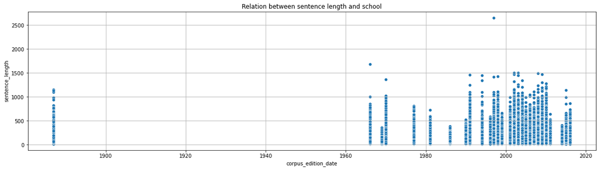

*Figure 1*

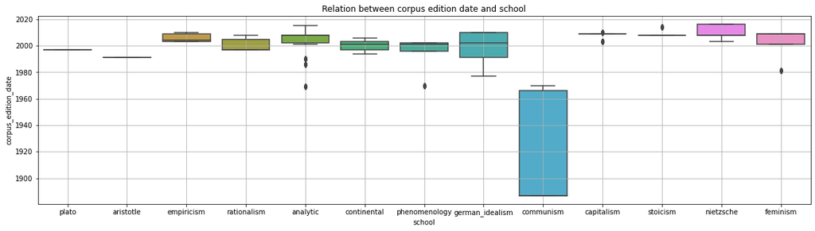

*Figure 2*

**Inference:**

From ScatterPlot - corpus edition date vs sentence length, we find that the year between 1890 and 1960 does not have any data points. No maximum or minimum sentence lengths are shown. This can only signify that no texts were published within that corpus edition dates.  
On creating a BoxPlot of corpus edition date vs school, we see that none of the schools except 'communism' goes before 1960. Even 'communism' has a minimum edition date of earlier than 1890. Thus, we can infer that between 1890 to 1960 none of the schools of thoughts published any form of corpus.

Let us confirm the above inference by creating a ScatterPlot - school vs corpus edition date. Using this, we will confirm that there are no schools publishing text between 1890 to 1960, while the school of 'communism' has edition dates right before 1890.

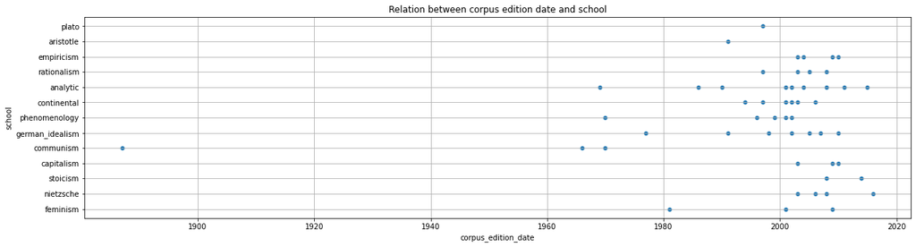

*Figure 3*

**Inference (Continued):**

**Question 2: The Emotion-Sentiment of Philosophy : Can the texts written by authors and within the schools be classified into varying emotions or general sentiments? If yes, how would that look like?**

The approach towards this problem is by using the pre-existing Python libraries to analyze the sentiments and emotions as presented by the texts. We perform the analysis in two parts. First part performs the Emotion Analysis of 5 authors namely -Epictetus, Descartes , Marcus Aurelius , Wollstonecraft , Berkeley. The emotions are divided into 4 categories: Happy, Sad, Angry, Surprise. Based on the classification of their texts into these emotions, we can try and realize certain characteristics of the authors.

```
Emotion Analysis PieChart - Epictetus.jpg  added to the /fig folder!
Emotion Analysis PieChart - Descartes.jpg  added to the /fig folder!
Emotion Analysis PieChart - Marcus Aurelius.jpg  added to the /fig folder!
Emotion Analysis PieChart - Wollstonecraft.jpg  added to the /fig folder!
Emotion Analysis PieChart - Berkeley.jpg  added to the /fig folder!

Run the next cell to display the Pie Charts!
```

[figure not shown]

*Figures 4*

**Inference:**

The texts are classified majorly in the following manner:  
1. Text by Epictetus: 'Sad' 41.75%.  
2. Text by Descartes: 'Surprise' 45.83%  
3. Text by Marcus Aurelius: 'Sad' 41.30%  
4. Text by Wollstonecraft: 'Sad' 47.14%  
5. Text by Berkley: 'Surprise' 42.61%

**Epictetus** was a believer of Stoic Ethics. He preached his ideas based on integrity, self-management, and personal freedom and his texts are known to be heartfelt and satirical in nature. This may be the reason that he recevied a classification under 'Sad'. This does not necessary show negative sentiment rather just the way he presented his views.  
**Descartes** was primarly a creative mathematician and an orginal metaphysician. I believe the reason that he was categorized under 'Surprise' was because he was a major contributor to universal laws. He was often attributed to mathematical theories and theory of nature. These form of texts cannot be classified into happy or sad, rather act as a surprising element to the larger audience.  
**Marcus Aurelius** was another Stoic believer. It is not a surprise that he received the 'Sad' categorization because he considered himself to be a follower of Epictetus. Thus, if the latter showed 'Sad' texts, it is reasonable to believe that Marcus Aurelius would also have an emotion of sadness in his texts.  
**Wollstonecraft** was an advocate of women's right and wrote novels highlighting the feministic views of that time. As feminism was an unfounded school of thought at that time, and there were lot of curelty towards women it makes sense that her text which tried to uplift women in the society were written with the emotion of 'Sad'.  
**Berkley** was another metaphysician and was considered a critic of Descartes. Thus, it follows that his texts do not revolve around Happy or sad nature rather surprises in its core of the concept of Idealism that he talks about.

Second part which answers Question 2 performs the Sentiment Analysis of all the 13 school of thoughts. It is divided into 3 categories - Positive, Negative and Neutral. Based on the classification of their texts into these sentiments, we can try and realize the general characteristics of the schools given in the dataset.

```
Sentiment Analysis of School- plato .jpg added to the /fig folder!
Sentiment Analysis of School- aristotle .jpg added to the /fig folder!
Sentiment Analysis of School- empiricism .jpg added to the /fig folder!
Sentiment Analysis of School- rationalism .jpg added to the /fig folder!
Sentiment Analysis of School- analytic .jpg added to the /fig folder!
Sentiment Analysis of School- continental .jpg added to the /fig folder!
Sentiment Analysis of School- phenomenology .jpg added to the /fig folder!
Sentiment Analysis of School- german_idealism .jpg added to the /fig folder!
Sentiment Analysis of School- communism .jpg added to the /fig folder!
Sentiment Analysis of School- capitalism .jpg added to the /fig folder!
Sentiment Analysis of School- stoicism .jpg added to the /fig folder!
Sentiment Analysis of School- nietzsche .jpg added to the /fig folder!
Sentiment Analysis of School- feminism .jpg added to the /fig folder!

Run the next cell to display the Pie Charts!
```

[figure not shown]

*Figures 5*

**Inference (Continued):**

The 13 Schools are classified majorly in the following manner:  
1. Positive: 9 out of 13  
2. Negative: 0  
3. Neutral: 4 out of 13

From the above data, we can easily start by saying that none of the Schools present a negative viewpoint. They can be sad or angry or confused but that does not signify that they are negative in nature. Thus the History of Philosophy has always encouraged positivity. It is easily seen that most school of thoughts were realized to create progress of the world around them. The concepts like feminism or capitalism is something that is much prevelant in today's world.  
Talking about the Schools that were categorized as Neutral, we notice that these schools are more tangible in nature. Analytical school is based on mathematics philosophers who contributed in metaphysics and mathematics. These topics cannot be considered as positive or negative rather have a neutral ground.

**Question 3: The Philosophy of Words : Can the basis of the author's philosophies be realized from their WordCloud representation?**

A **WordCloud** helps in highlighting the words that are often used in a given text. Here we analyze the wordcloud of 5 authors - Marx, Plato, Aristotle, Leibniz and Locke. To answer the question, we will look at the larger words (most often used) and compare it with what we know about the authors beliefs and see if they match.

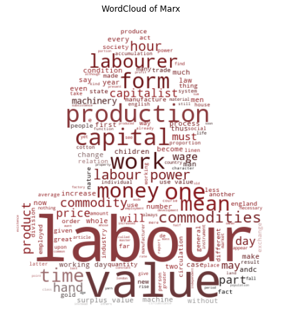

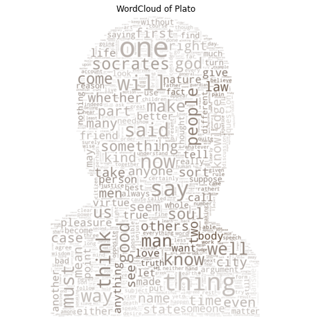

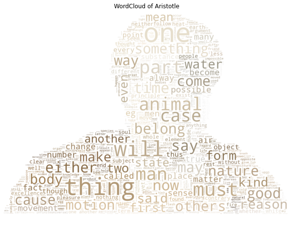

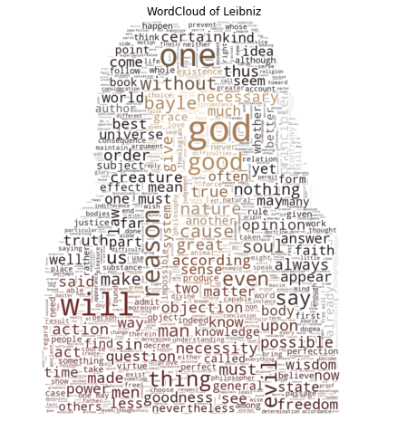

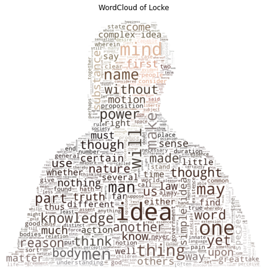

*Figures 6*

**Inference:**

Using reference from https://plato.stanford.edu/index.html, we can analyze the prominent words as shown by the wordcloud and realize whether they are true to the authors basic belief.  
The words shown by the wordcloud of **Marx** revolve around economy and industrialization. Marx was known to be an socialist revolutionary and critic of political economy. Marxism, named after him, examines the effect of capitalism on labor, productivity, and economic development and argues for a worker revolution to overturn capitalism in favor of communism.  
**Plato** was a student of Socrates, so it makes sense that it is one of common words in his texts. Besides that Plato was a revolutionary person in the field of Philosophy and is attributed towards defining the meaning of Philosophy. Additionally, **Aristotle** was Plato's student and colleague for around 20 years, so it is no surprise that the prominent words match with that of Plato's as the idealogies of both of them are concurrent in nature.  
**Leibniz** believed that God freely chose the best world from an infinite number of possible worlds and that a person could be said to act freely when the contrary of that action does not imply a contradiction. Hence, the prominent words in his texts like 'god', 'reason' , 'will' indicate this very belief of his.  
**Locke** wrote a monumental piece titles - "An Essay Concerning Human Understanding" which depicts the cruz of what human can understand and what one cannot. This seems to be in line with the words like 'mind', 'thought' and 'idea'.

Thank you for reading this blog on Philosophy Data Project!  
The GitHub Link for the raw code is: https://github.com/TZstatsADS/spring-2022-prj1-Rishav1999